# Explore catch

```r
params <- params |>
    calibrateYield() |> steady() |> matchBiomasses() |> steady() |>
    calibrateYield() |> steady() |> calibrateYield() |> steady() |>
    calibrateYield() |> steady() |> calibrateYield() |> steady() |>
    calibrateYield() |> steady() |> calibrateYield() |> steady() |>
    calibrateYield() |> steady() |> calibrateYield() |> steady() |>
    calibrateYield() |> steady() |> calibrateYield() |> steady() |>
    calibrateYield() |> steady() |> calibrateYield() |> steady() |>
  calibrateYield() |> steady() |> calibrateYield() |> steady() |>
    calibrateYield() |> steady() |> calibrateYield() |> steady() |>
    calibrateYield() |> steady() |> calibrateYield() |> steady() |>
    calibrateYield() |> steady() |> calibrateYield() |> steady() |>
    calibrateYield() |> steady() |> calibrateYield() |> steady() |>
    calibrateYield() |> steady() |> calibrateYield() |> steady() |>
    calibrateYield() |> steady() |> calibrateYield() |> steady() |>
    calibrateYield() |> steady() |> calibrateYield() |> matchBiomasses() |> steady()
```

[output not shown]

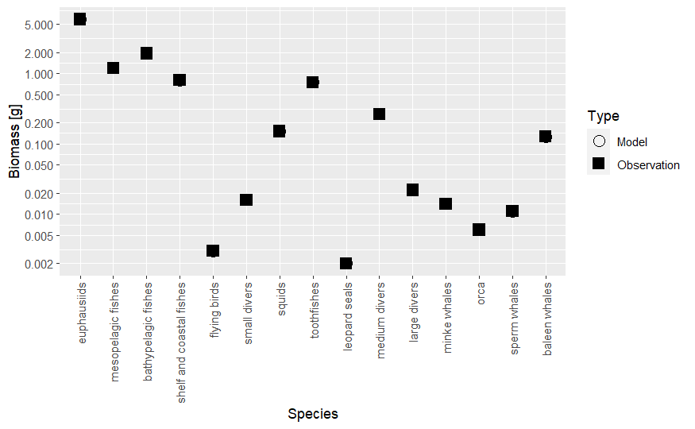

```r
plotBiomassVsSpecies(params)
```

```r
plotlySpectra(params_v3)
```

[output not shown]

Save species params to work with in therMizer workshop

|  | species | gear | sel_func | knife_edge_size | catchability |
| --- | --- | --- | --- | --- | --- |
| euphausiids, knife_edge_gear | euphausiids | knife_edge_gear | knife_edge | 1.584893e-02 | 1 |
| mesopelagic fishes, knife_edge_gear | mesopelagic fishes | knife_edge_gear | knife_edge | 1.127500e+01 | 1 |
| bathypelagic fishes, knife_edge_gear | bathypelagic fishes | knife_edge_gear | knife_edge | 6.255000e+01 | 1 |
| shelf and coastal fishes, knife_edge_gear | shelf and coastal fishes | knife_edge_gear | knife_edge | 4.675000e+01 | 1 |
| flying birds, knife_edge_gear | flying birds | knife_edge_gear | knife_edge | 1.718542e+03 | 1 |
| small divers, knife_edge_gear | small divers | knife_edge_gear | knife_edge | 4.266667e+03 | 1 |
| squids, knife_edge_gear | squids | knife_edge_gear | knife_edge | 1.280543e+02 | 1 |
| toothfishes, knife_edge_gear | toothfishes | knife_edge_gear | knife_edge | 1.276520e+04 | 1 |
| leopard seals, knife_edge_gear | leopard seals | knife_edge_gear | knife_edge | 8.700000e+04 | 1 |
| medium divers, knife_edge_gear | medium divers | knife_edge_gear | knife_edge | 2.947500e+05 | 1 |

[output cut: 5 more lines]

Adjust catchability to only select fishing on species with catch data

```r
gear_params(params)$catchability <-  c(0, 0, 0, 0, 0, 0, 0, 0, 0, 0, 0, 1, 1, 1, 1)
```

Find minimum sizes caught to adjust knife_edge_size

```r
df_catch_size <- df_yield %>%
  group_by(Species) %>%
  summarise(median_size = median(Weight_kg),
            median_size_g = median_size * 1000)

df_catch_size
```

| Species | median_size | median_size_g |
| --- | --- | --- |
| Antarctic Minke | 7148.531 | 7148531 |
| Baleen | 59247.338 | 59247338 |
| Bottlenose | 14006.351 | 14006351 |
| Killer | 3132.264 | 3132264 |
| Sperm | 36312.791 | 36312791 |

Catchability: 1 value Effort changes through time (voyage frequency and length)

|  | species | gear | sel_func | knife_edge_size | catchability | l50 | l25 |
| --- | --- | --- | --- | --- | --- | --- | --- |
| euphausiids, Main | euphausiids | Main | sigmoid_length | 1.584893e-02 | 0 | 1 | 0.8 |
| mesopelagic fishes, Main | mesopelagic fishes | Main | sigmoid_length | 1.127500e+01 | 0 | 5 | 4.0 |
| bathypelagic fishes, Main | bathypelagic fishes | Main | sigmoid_length | 6.255000e+01 | 0 | 5 | 4.0 |
| shelf and coastal fishes, Main | shelf and coastal fishes | Main | sigmoid_length | 4.675000e+01 | 0 | 5 | 4.0 |
| flying birds, Main | flying birds | Main | sigmoid_length | 1.718542e+03 | 0 | 10 | 8.0 |
| small divers, Main | small divers | Main | sigmoid_length | 4.266667e+03 | 0 | 10 | 8.0 |
| squids, Main | squids | Main | sigmoid_length | 1.280543e+02 | 0 | 10 | 8.0 |
| toothfishes, Main | toothfishes | Main | sigmoid_length | 1.276520e+04 | 0 | 20 | 16.0 |
| leopard seals, Main | leopard seals | Main | sigmoid_length | 8.700000e+04 | 0 | 20 | 16.0 |
| medium divers, Main | medium divers | Main | sigmoid_length | 2.947500e+05 | 0 | 20 | 16.0 |

[output cut: 5 more lines]

```r
params <- setParams(setFishing(params, initial_effort = 1))

params_v1 <- steady(params)
```

```
Convergence was achieved in 57 years.
Warning: The following species require an unrealistic reproductive efficiency greater than 1: mesopelagic fishes, bathypelagic fishes, shelf and coastal fishes, squids, minke whales, orca, sperm whales, baleen whales
```

```r
model <- project(params_v1, effort=1)
```

[output not shown]

[output cut: 24 more lines]

[output not shown]

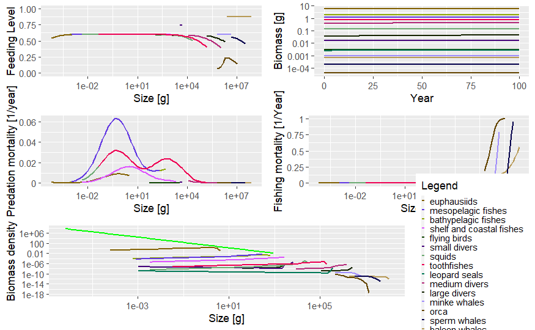

```r
plot(model)
```

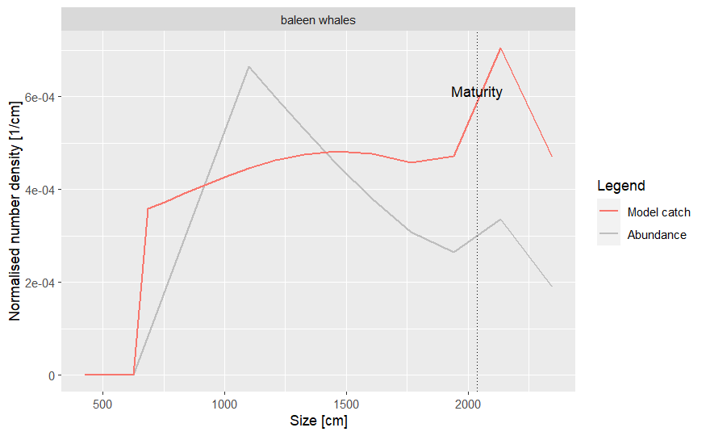

```r
plotYieldVsSize(model, species = "baleen whales",
                x_var = "Length")
```

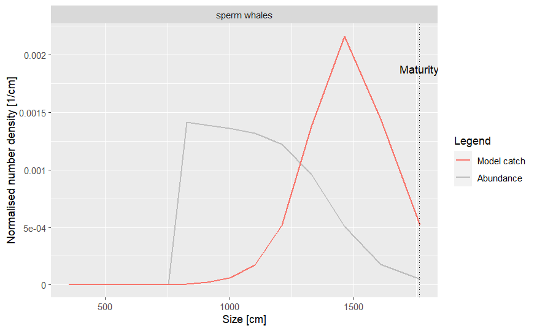

```r
plotYieldVsSize(model, species = "sperm whales",
                x_var = "Length")
```

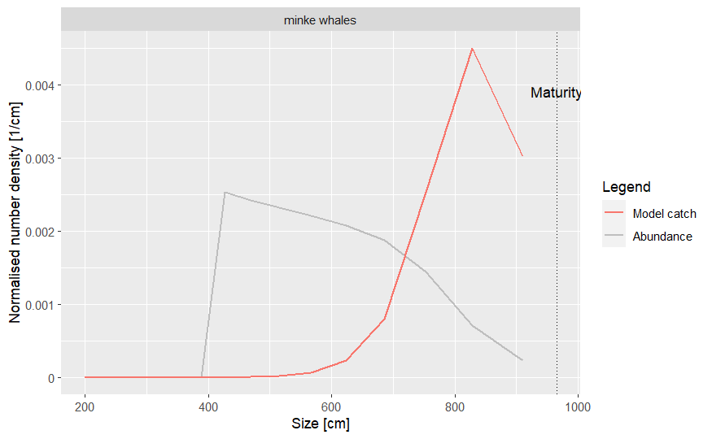

```r
plotYieldVsSize(model, species = "minke whales",
                x_var = "Length")
```

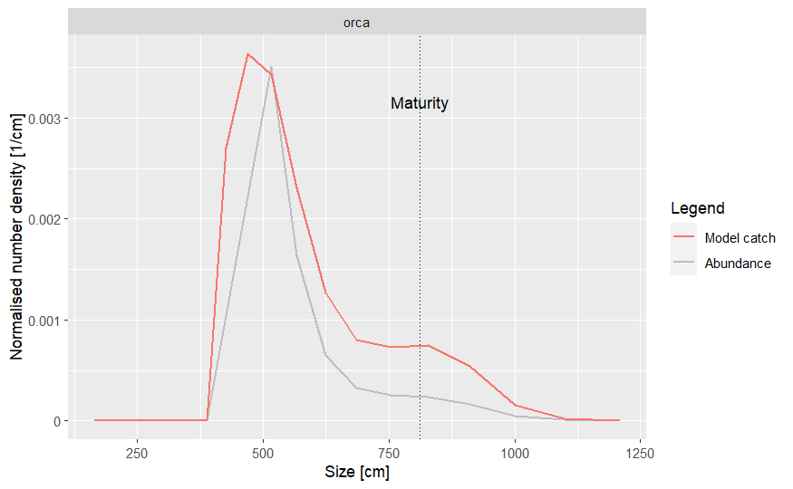

```r
plotYieldVsSize(model, species = "orca",
                x_var = "Length")
```

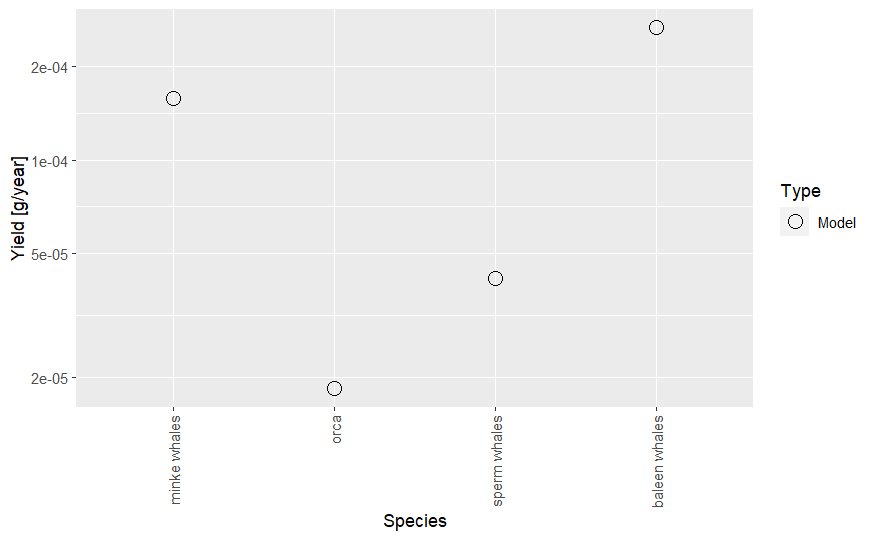

```r
plotYieldVsSpecies(params_v1)
```

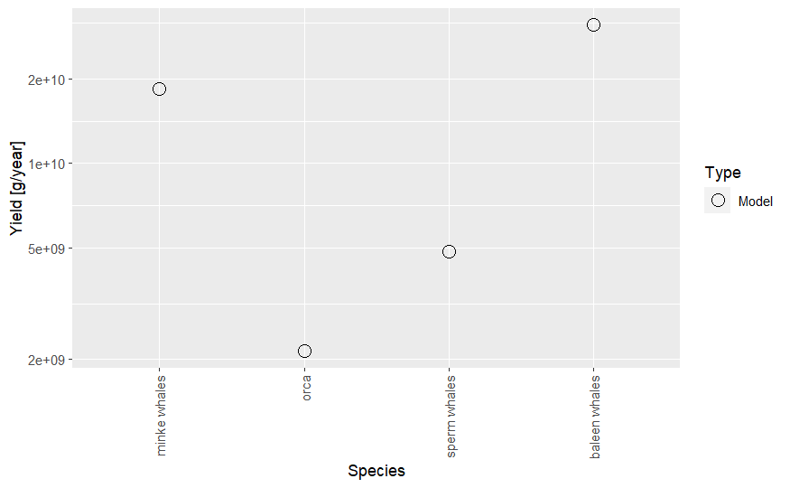

```r
model_c1 <- calibrateYield(params_v1)
plotYieldVsSpecies(model_c1)
```

```r
scaling_factor <- initialN(model_c1)[1, 1] / initialN(model)[1, 1]
scaling_factor
```

```
[1] 1.166251e+14
```

```r
# Rescale the observed biomass values by that factor
species_params(model_c1)$biomass_observed <-
    species_params(model_c1)$biomass_observed * scaling_factor
```

[figure not shown]

```r
model_s1 <- steady(model_c1)
```

```
Convergence was achieved in 1.5 years.
Warning: The following species require an unrealistic reproductive efficiency greater than 1: euphausiids, squids, toothfishes, leopard seals, minke whales, orca, sperm whales, baleen whales
```

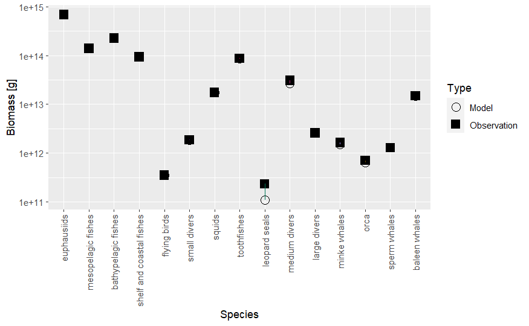

```r
plotBiomassVsSpecies(model_s1)
```

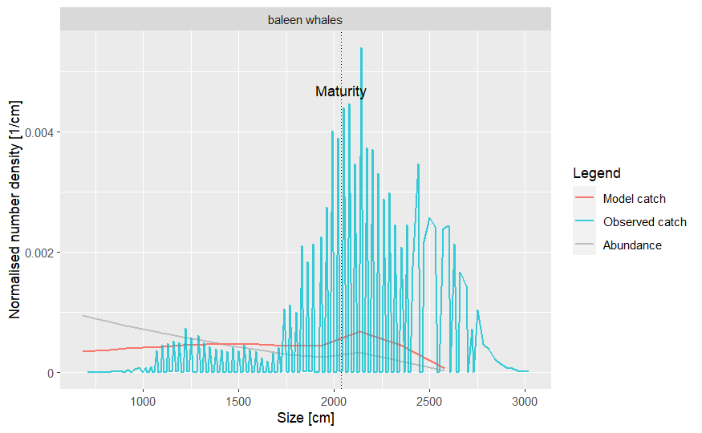

```r
plotYieldVsSize(model_s1, species = "baleen whales", catch = catch_lengths,
                x_var = "Length")
```

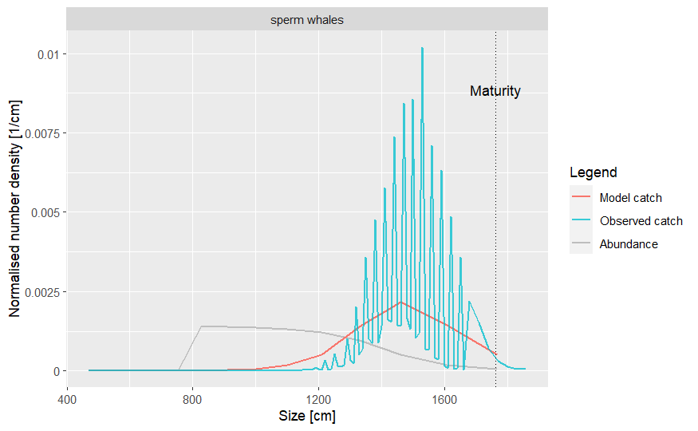

```r
plotYieldVsSize(model_s1, species = "sperm whales", catch = catch_lengths,
                x_var = "Length")
```

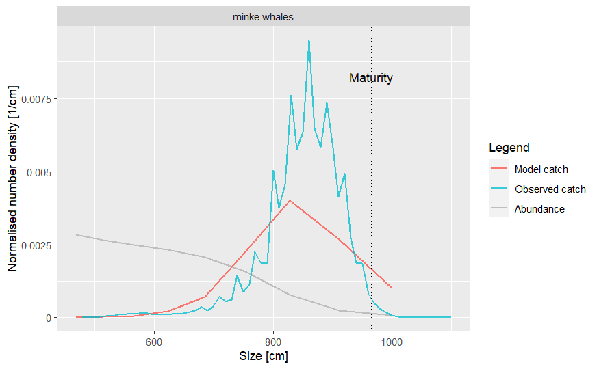

```r
plotYieldVsSize(model_s1, species = "minke whales", catch = catch_lengths,
                x_var = "Length")
```

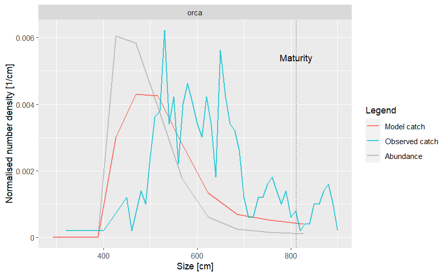

```r
plotYieldVsSize(model_s1, species = "orca", catch = catch_lengths,
                x_var = "Length")
```

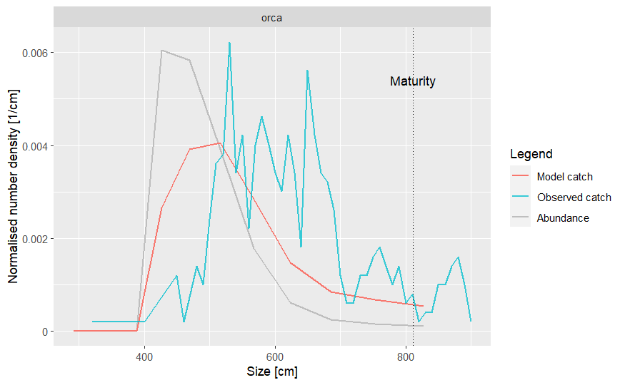

```r
# Modify the l50 and l25 for breams
gear_params(model_s1)["orca, Main", "l25"] <- 550
gear_params(model_s1)["orca, Main", "l50"] <- 650

#check the match between model and observed catch size distributions
plotYieldVsSize(model_s1, species = "orca", catch = catch_lengths,
                x_var = "Length")
```

```r
NA
NA
```

```r
model_s2 <- steady(model_s1)
```

```
Convergence was achieved in 51 years.
Warning: The following species require an unrealistic reproductive efficiency greater than 1: euphausiids, toothfishes, leopard seals, minke whales, orca, sperm whales, baleen whales
```

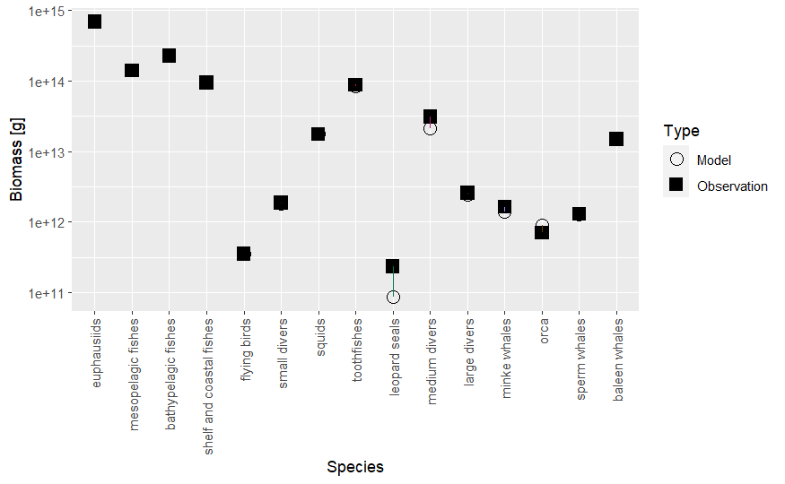

```r
plotBiomassVsSpecies(model_s2)
```

```r
model_tuned_v1 <- tuneParams(model_s2)

model_tuned_v1 <- tuneParams(model_tuned_v1)

model_tuned_v1 <- tuneParams(model_tuned_v1)

model_tuned_v1 <- tuneParams(model_tuned_v1)
```

```r
model_tuned_v2 <- tuneParams(model_tuned_v1)

model_tuned_v2 <- tuneParams(model_tuned_v2)

# saveRDS(model_tuned_v2, "model_tuned_catch_vXX.rds")
```

[figure not shown]

```r
model_proj_v2 <- project(params_cy_v2, t_max = 200)
```

[output not shown]

[output cut: 55 more lines]

[output not shown]

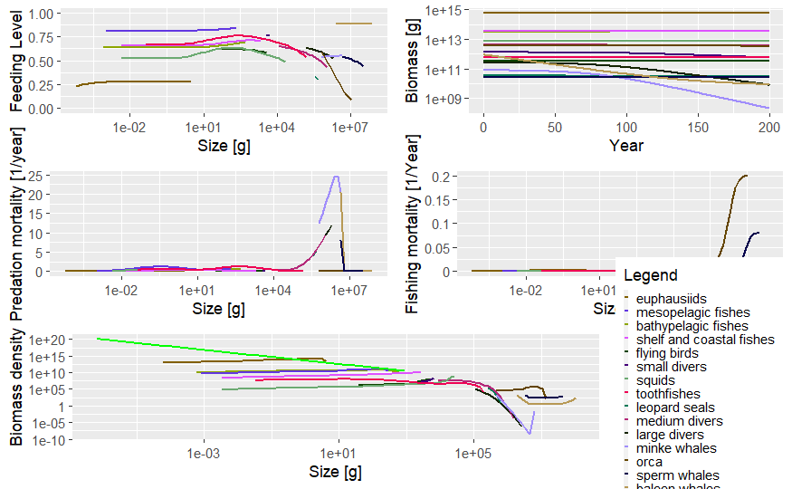

```r
plot(model_proj_v2)
```

[figure not shown]

[figure not shown]

Effort through time: sigmoidal size selectivity curve: hand calibrate or fit curve to it with (week 2 of course 1plotYieldvsSize) Size selectivity Approach

Or stylised effort function and test multiple hypothesis of what that looked like to match the catch timeseries: effort evolution through time approach

Progressive depletion of the whale abundance (existing papers) Caused by collapse? Shift in effort or did they reach a tipping point or was it a progressive reduction of larger

Does a shift in body size distributions emerge from the inclusion of fishing

Shift from one species to another versus equal effort and then the vulnerability would lead to differences in response.

Dynamics of effort curve and what curve ‘shape’ matches the catch data the best? Is it a long drawn out max effort or a rapid shift (i.e., steep inflection point)

To add stochasticity: check github (https://github.com/juliablanchard/fisheries_stability)

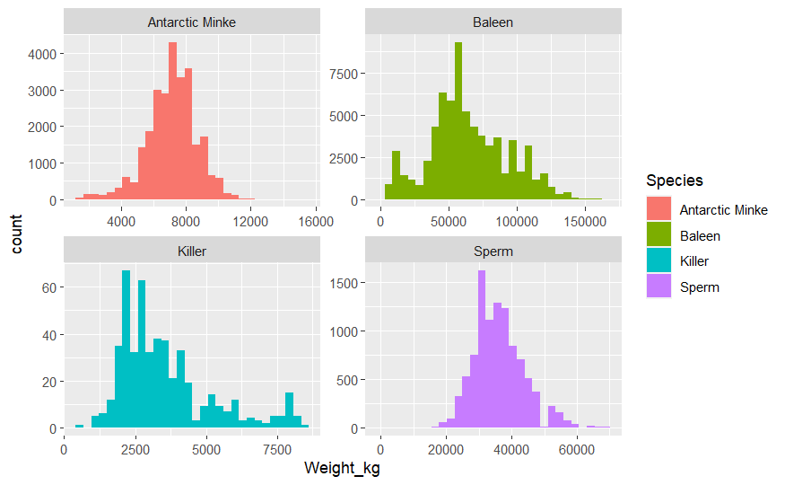

```r
df_yield %>%
  filter(!Species == "Bottlenose") %>%
ggplot(aes(x=Weight_kg, fill=Species)) +
 geom_histogram(position = 'identity') +
  facet_wrap(~Species, scales = "free")
```